# CITS4009: Computational Data Analysis - Project 2 - Modelling

### Project Distribution

Waleed Khalid Siraj (23803313) (50%): Saif Ali Athyaab (23810756) (50%):

[YouTube video link](https://youtu.be/a0E0aEiF_aE)

## Introduction

### Data Description

The data set analyzed can be obtained from the Kaggle platform. It’s part of the “Global YouTube Statistics 2023” challenge. https://www.kaggle.com/datasets/nelgiriyewithana/global-youtube-statistics-2023

YouTube.com is a video-sharing platform that allows users to upload, watch, and interact with videos from all over the world.The Global YouTube Statistics 2023 dataset is a collection of data about YouTube channels, videos, and their respective view counts. The data set spans from January 2023 to March 2023, and includes information about the channel’s name, country, subscriber count, video title, view count, and category.

### Data Sources

Understanding the socio-economic context in which YouTube channels thrive is vital for comprehending their patterns and trends. Thus, this analysis incorporates additional data from the World Bank to assess the impact of Gross Domestic Product (GDP) per capita and other socio-economic factors on YouTube channel creation and performance[5]. The choice to include data from 2005 to 2022 was motivated by the fact that YouTube was established in 2005, and analyzing the years following its launch provides insights into the platform’s evolution and the growth of YouTube content creators.

### Data Preprocessing

Load libraries

```r
library(forcats)
library(gridExtra)
library(tidyverse)
library(vtreat)
library(dplyr)
library(reshape2)
library(ROCR)
library(knitr)
library(ggplot2)
library(crayon)
library(ROCit)
library(e1071)
library(rpart)
library(rpart.plot)
library(pander)
library(lime)
library(pROC)
```

Data preprocessing is a crucial step in ensuring that the dataset is in a suitable format for analysis. Missing data can significantly impact the accuracy of the analysis. To address this issue, the CSV file “youtube_UTF_8.csv” was read into R, with careful consideration given to the presence of missing values represented by the string “nan”. Using the na.strings argument in the read.csv function, these “nan” entries were transformed into standard missing value representations (NA) in R, enhancing the data’s consistency and analytical potential.

To better understand the socio-economic context surrounding YouTube channel creation and performance, the World Bank data was integrated into the analysis. Only the relevant columns (i.e., “Country Name” and “Code”) were retained, alongside a newly calculated variable, “Average GDP per Capita.” The latter was computed as the mean of GDP per capita values from 2005 to 2022. Merging this World Bank data with the original dataset using “Country” as the key variable enabled the study to consider how economic factors could influence YouTube channel-related phenomena.

The “channel_age” variable was introduced, allowing us to gauge the duration of YouTube channels’ existence. This age calculation was based on the most recent date found in the dataset and each channel’s creation date. In cases where the creation date was missing or mislabeled as “1970-01-01,” these entries were corrected to NA to maintain data integrity.

The adoption of this data-driven approach, coupled with data preprocessing techniques, aims to set the stage for a comprehensive analysis of YouTube channel performance and longevity in the context of socio-economic factors.

```r
gys.data <- read.csv("youtube_UTF_8.csv",stringsAsFactors=T,na.strings = "nan",encoding = 'UTF-8')
#Reading in the world bank dataset
#Taking in only 2005 to 2022 columns
wbd <- read.csv("API_NY.GDP.PCAP.CD_DS2_en_csv_v2_5871588.csv",header=TRUE)
wbd <- wbd[,c(1,2,50:67)]
#Calculating Avergae GDP per capita from 2005 to 2022
wbd$Average_GDP_PCAP <- rowMeans(wbd[,3:20], na.rm=TRUE)
#Keeping only Country Name, Code, calculated column
wbd2 <- wbd[,c(1,2,21)]
#Merging with WDB data by Country as the KEY
s1 <- merge(gys.data,wbd2, by.x ="Country", by.y="Country.Name", all.x=TRUE)

#Calculating Rural population
attach(s1)
#s1$Rural_population <- Population - Urban_population

s1$date_n <- as.Date(paste(s1$created_year, s1$created_month, s1$created_date, sep = "-"), format = "%Y-%b-%d")

s1$date_n[s1$date_n=="1970-01-01"] <- NA
#Using the most recent youtube channel to calculate age of channel
date_rec <- max(s1$date_n, na.rm = TRUE)
s1$channel_age <- as.numeric(date_rec - s1$date_n)
```

## Classification

### Choosing the response (target) variable

The response variable for our classification task was chosen as the dichotomy between “old” and “new” channels. This demarcation was established by utilizing February 14, 2012, as a reference date. On this date, YouTube introduced its Partner Program, a significant milestone in the platform’s history. It marked the moment when content creators were provided with opportunities for monetization[6]. This distinct transition in the platform’s evolution serves as an effective reference point, dividing channels into “old” (predating the Partner Program) and “new” (created after its introduction). To reflect this distinction in the dataset, we assigned the value -1 to “old” channels and 1 to “new” channels.

```r
#Feb 14, 2012 (Introduction of YouTube Partner Program)
date_ref <- as.Date("2012-02-14")

s1$oldNew <- ifelse(s1$channel_age > as.numeric(date_rec- date_ref), -1, 1)

sv <- subset(s1, select = -c(rank,Youtuber,Title,video_views_rank,date_n,lowest_monthly_earnings,lowest_yearly_earnings,highest_yearly_earnings, created_year, created_month, created_date, Country.Code,channel_age,Latitude,Longitude,Urban_population,Abbreviation))
detach(s1)
summary(s1$oldNew)
```

```
##    Min. 1st Qu.  Median    Mean 3rd Qu.    Max.    NA's
## -1.0000 -1.0000  1.0000  0.1911  1.0000  1.0000       6
```

To ensure the model’s efficacy and interpretability, it is crucial to refine the dataset by removing superfluous and highly correlated columns. Consequently, we adopted a pragmatic approach. Columns representing “Rank,” “Youtuber” (channel owner), “Title,” “Video Views Rank,” “Date,” “Lowest Monthly Earnings,” “Lowest Yearly Earnings,” “Highest Yearly Earnings,” “Created Year,” “Created Month,” “Created Date,” “Country Code,” and “Channel Age” were excluded from the dataset. These columns were either non-contributory to our classification task or presented issues like high cardinality or uniqueness.

The output of our classification process indicates that 400 channels are classified as “old,” 589 channels as “new,” and 6 instances contain missing data. This ratio of old to new channels provides a fundamental insight into the distribution of our response variable and will serve as a benchmark for model performance assessment. Understanding this distribution is pivotal as it can have a profound impact on the choice of evaluation metrics and model behavior.

### Data Cleaning

Missing data is a common issue in real-world datasets, and addressing it is paramount to avoid biased or misleading results. In our dataset, missing values were strategically handled in categorical columns. To facilitate this process, a custom function, “add_missing,” was devised and applied to each categorical column.

Ensuring data consistency and clarity is a fundamental aspect of data cleaning. In our dataset, certain column names were modified to enhance consistency and prevent future mismatches. Specifically, columns were renamed to align with their original column names, safeguarding the integrity of our dataset.

Categorical and numerical columns are distinct data types, and treating them differently is pivotal in the modeling process. For this reason, we separated the names of these two types of columns for targeted data preprocessing. This segregation aids in maintaining the structural integrity of the dataset while enabling focused operations on each data type.

Numerical columns with missing values required specific treatment. We employed a missingness treatment strategy to impute the missing data. This method ensures that the integrity of the numerical data is preserved, which is crucial for subsequent analyses

The treated categorical and numerical columns were consolidated into a single prepared data frame labeled “d.” To maintain continuity, the response variable “oldNew” was reintegrated into this dataset.

```r
add_missing <- function(column_old) {
  column_new <- column_old
  levels(column_new) <- c(levels(column_old), "Missing")
  for (i in 1:length(column_new)) {
  if (is.na(column_new[i])) {
    column_new[i] <- "Missing"
  }
  }
  column_new
}
outcome <- 'oldNew'
pos <- '1'
sv <- sv %>% rename(Unemployment_rate := Unemployment.rate,
       video_views := video.views,
       GTEE := starts_with("Gross.tertiary"))
vars <- setdiff(colnames(sv), outcome)

catVars <- vars[sapply(sv[, vars], class) %in% c('factor', 'character')]
numericVars <- vars[sapply(sv[, vars], class) %in% c('numeric', 'integer')]
for (i in catVars){
  sv[,i] <- add_missing(sv[,i])
}

svNum <- sv[,numericVars]
svCat <- sv[,catVars]
treatment_plan <- design_missingness_treatment(svNum)
svNum <- prepare(treatment_plan,svNum)

svNum <- svNum %>% select(-contains("isBAD"))
d <- cbind(svNum,svCat)
d$oldNew <- sv$oldNew
d <- na.omit(d)
```

### Data Splitting

We begin by setting a random seed (in this case, 729375) to ensure the reproducibility of our results. Then, a random grouping variable, “rgroup,” is created to facilitate data splitting. The “rgroup” variable is filled with random uniform values, ensuring that approximately 90% of the data is allocated to the training set, and the remaining 10% is designated for the validation (or calibration) set.

Once the data is split, a distinction is made between categorical and numerical features. Categorical variables, including those initially labeled as “factor” or “character,” are grouped as “catVars.” Similarly, numerical variables, including those of “numeric” or “integer” type, are grouped as “numericVars.”

```r
set.seed(729375)
d$rgroup <- runif(nrow(d))
dTrainAll <- subset(d, rgroup<=0.9)
dTest <- subset(d, rgroup > 0.9)

vars <- setdiff(colnames(dTrainAll), c(outcome,'rgroup'))

catVars <- vars[sapply(dTrainAll[,vars], class) %in% c('factor','character')]
numericVars <- vars[sapply(dTrainAll[,vars], class) %in% c('numeric','integer')]
# split dTrainAll into a training set and a validation (or calibration) set
useForCal <- rbinom(n=dim(dTrainAll)[[1]], size=1, prob=0.1) > 0
dCal <- subset(dTrainAll, useForCal)
dTrain <- subset(dTrainAll,!useForCal)
```

Data partitioning is a fundamental practice in machine learning, ensuring that our models are tested on unseen data to assess their generalizability. This process begins with splitting the training data, “dTrainAll,” into two segments: a training set (“dTrain”) and a validation (or calibration) set (“dCal”). The split is strategically conducted, employing a binomial distribution to randomly assign a portion of the data to the calibration set.

The division helps us develop and refine our models on one subset of the data, while simultaneously validating and tuning them on another. It also mitigates the risk of overfitting, which occurs when models are excessively tailored to the training data and fail to perform well on new, unseen data.

This feature selection and data splitting phase is crucial for the subsequent building and evaluation of classification models. The process ensures that we use the most informative features and employ an effective model validation strategy. The results obtained from these steps will be discussed in the forthcoming sections of our project.

### Single Variable Models

We applied the mkPredC function to all categorical variables. This function performs single variable prediction for a given categorical column. It calculates the probability of a positive outcome based on the proportion of positive outcomes for each level in the column. The function also accounts for missing values, ensuring they are handled appropriately during the calculation.

For numerical variables, we transformed them into categorical variables using quantiles and the cut function. The mkPredN function was then applied, which internally uses the mkPredC function for these categorical representations of numerical data.

```r
# perform single variable prediction for a given categorical column
mkPredC <- function(outCol, varCol, appCol) {
  pPos <- sum(outCol == pos,na.rm = TRUE) / length(outCol)
  naTab <- table(as.factor(outCol[is.na(varCol)]),useNA = 'ifany')
  pPosWna <- (naTab/sum(naTab))[pos]
  vTab <- table(as.factor(outCol), varCol)
  pPosWv <- (vTab[pos, ] + 1.0e-3*pPos) / (colSums(vTab) + 1.0e-3)
  pred <- pPosWv[appCol]
  pred[is.na(appCol)] <- pPosWna
  pred[is.na(pred)] <- pPos
  pred
}

mkPredN <- function(outCol, varCol, appCol) {
  cuts <- unique(as.numeric(
    quantile(varCol, probs=seq(0, 1, 0.1), na.rm=T)))
  varC <- cut(varCol, cuts)
  appC <- cut(appCol, cuts)
  mkPredC(outCol, varC, appC)
}

for (v in catVars) {
  pi <- paste('pred', v, sep='')
  dTrain[,pi] <- mkPredC(dTrain[,outcome], dTrain[,v], dTrain[,v])
  dCal[,pi] <- mkPredC(dTrain[,outcome], dTrain[,v], dCal[,v])
  dTest[,pi] <- mkPredC(dTrain[,outcome], dTrain[,v], dTest[,v])
}

for(v in numericVars) {
pi <- paste('pred', v, sep='')
dTrain[,pi] <- mkPredN(dTrain[,outcome], dTrain[,v], dTrain[,v])
dCal[,pi] <- mkPredN(dTrain[,outcome], dTrain[,v], dCal[,v])
dTest[,pi] <- mkPredN(dTrain[,outcome], dTrain[,v], dTest[,v])
}
```

These functions were applied to both the training and calibration sets (dTrain and dCal) and the results were stored in the corresponding data frames.

We utilized the calcAUC function to compute the AUC values. The results were stored in a data frame, where each row represented a variable, and the corresponding AUC values for training and calibration were recorded. We focused on variables with AUC values greater than or equal to 0.6, ensuring that only meaningful and interpretable results were included in the analysis.

The data frame was subsequently sorted in descending order based on the Calibration AUC values. This enabled us to identify the most significant variables for our classification models. The sorted data frame provides a clear understanding of the performance of each variable in the context of the classification task.

The results of the AUC analysis will be used to inform the selection of variables for the subsequent stages of the classification process. They will also serve as a guide for the development of more complex models in the later sections of our analysis.

```r
calcAUC <- function(predcol,outcol) {
  perf <- performance(prediction(predcol,outcol==pos),'auc')
  as.numeric(perf@y.values)
}


# Create an empty data frame to store AUC values
auc_df <- data.frame(Variable = character(0), Train_AUC = numeric(0), Calibration_AUC = numeric(0))

for (v in c(catVars, numericVars)) {
  pi <- paste('pred', v, sep='')
  aucTrain <- calcAUC(dTrain[, pi], dTrain[, outcome])
  if (aucTrain >= 0.6) {
    aucCal <- calcAUC(dCal[, pi], dCal[, outcome])

    # Add the AUC values to the data frame
    auc_df <- rbind(auc_df, data.frame(Variable = pi, Train_AUC = aucTrain, Calibration_AUC = aucCal))
  }
}
auc_df <- auc_df[order(-auc_df$Calibration_AUC),]
# View the data frame with AUC values
print(auc_df)
```

```
##                            Variable Train_AUC Calibration_AUC
## 9                    predPopulation 0.6069685       0.7177939
## 10             predAverage_GDP_PCAP 0.6180667       0.6706924
## 2                      predcategory 0.7016384       0.6561997
## 3                  predchannel_type 0.7099977       0.6517713
## 1                       predCountry 0.6836511       0.5994364
## 5                       preduploads 0.6573540       0.5905797
## 8                          predGTEE 0.6044312       0.5813205
## 7  predsubscribers_for_last_30_days 0.6031099       0.5692432
## 6             predchannel_type_rank 0.6014721       0.5656200
## 4                   predvideo_views 0.6226853       0.4742351
```

We selected a set of variables, encompassing both categorical and numerical ones, to examine their performance using the cross-validation process. For each variable, we performed 100 repetitions of cross-validation, ensuring comprehensive coverage. In each repetition, we randomly split the data into two subsets: one for training and the other for calibration. This randomization technique allowed us to gauge the variability in model performance.

A critical performance metric, the Area Under the Curve (AUC), was computed for each repetition. This metric provided insights into the predictive power of each variable. Specifically, we calculated the mean and standard deviation of the AUC values across the 100 repetitions. These statistics offer valuable information about the consistency and reliability of the single-variable models.

```r
#100-fold cross validation
vars <- c(catVars,numericVars)
for (var in vars) {
aucs <- rep(0,100)
for (rep in 1:length(aucs)) {
useForCalRep <- rbinom(n=nrow(dTrainAll), size=1, prob=0.1) > 0
predRep <- mkPredC(dTrainAll[!useForCalRep, outcome], dTrainAll[!useForCalRep, var], dTrainAll[useForCalRep, var])
aucs[rep] <- calcAUC(predRep, dTrainAll[useForCalRep, outcome])
}
print(sprintf("%s: mean: %4.3f; sd: %4.3f", var, mean(aucs), sd(aucs)))
}
```

```
## [1] "Country: mean: 0.609; sd: 0.052"
## [1] "category: mean: 0.663; sd: 0.053"
## [1] "channel_type: mean: 0.672; sd: 0.056"
## [1] "subscribers: mean: 0.500; sd: 0.000"
## [1] "video_views: mean: 0.500; sd: 0.000"
## [1] "uploads: mean: 0.495; sd: 0.055"
## [1] "country_rank: mean: 0.532; sd: 0.059"
## [1] "channel_type_rank: mean: 0.482; sd: 0.062"
## [1] "video_views_for_the_last_30_days: mean: 0.492; sd: 0.027"
## [1] "highest_monthly_earnings: mean: 0.500; sd: 0.020"
## [1] "subscribers_for_last_30_days: mean: 0.507; sd: 0.024"
## [1] "GTEE: mean: 0.512; sd: 0.068"
## [1] "Population: mean: 0.500; sd: 0.000"
## [1] "Unemployment_rate: mean: 0.549; sd: 0.062"
## [1] "Average_GDP_PCAP: mean: 0.500; sd: 0.000"
```

Plotting the top predictor variables according to AUC. the double density plot is useful for inspecting the predicted probabilities

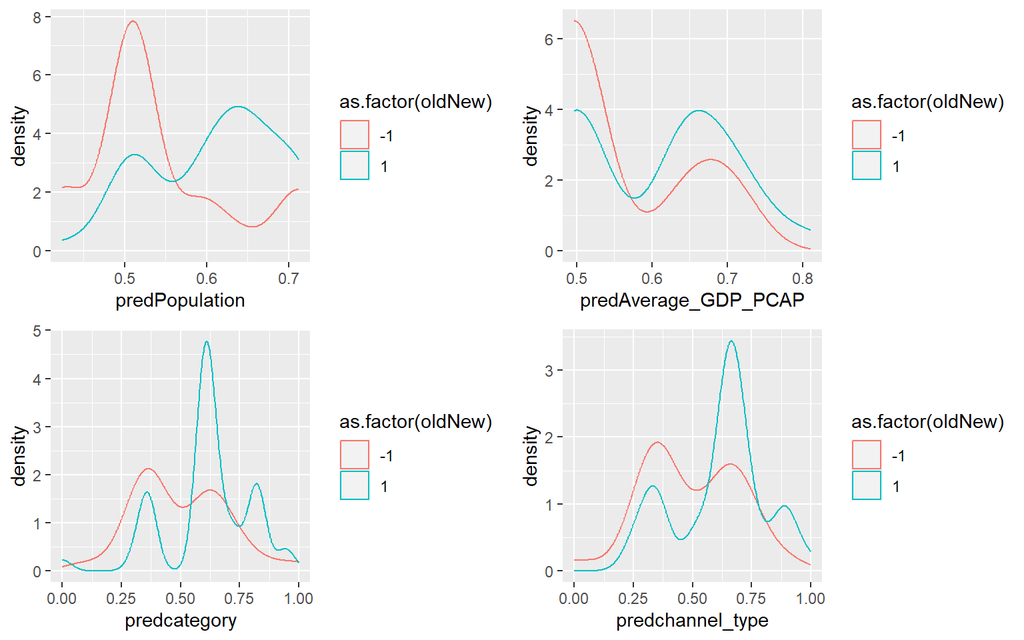

```r
fig1 <- ggplot(dCal) + geom_density(aes(x=predPopulation, color=as.factor(oldNew)))
fig2 <- ggplot(dCal) + geom_density(aes(x=predAverage_GDP_PCAP, color=as.factor(oldNew)))
fig3 <- ggplot(dCal) + geom_density(aes(x=predcategory, color=as.factor(oldNew)))
fig4 <- ggplot(dCal) + geom_density(aes(x=predchannel_type, color=as.factor(oldNew)))
grid.arrange(fig1, fig2,fig3,fig4, ncol=2)
```

Figure 1 - Population vs. Channel Age: The first plot illustrates the density of predicted probabilities for the “Population” variable, categorized by channel age (“old” or “new”). When observing this chart, it becomes apparent that high population values tend to correspond to new channels. This implies that channels in regions with larger populations are more likely to be recently established.

Figure 2 - Average GDP per Capita vs. Channel Age: The second plot presents the density of predicted probabilities for “Average GDP per Capita,” again separated by channel age. It suggests that high GDP per capita values are associated with new channels. This finding indicates that channels in economically prosperous regions tend to be newer.

Figure 3 - Category vs. Channel Age: The third plot visualizes the density of predicted probabilities based on the “Category” variable, distinguishing between old and new channels. Here, we observe that channels with higher values of “Category” prediction are more likely to be new. This signifies that certain video categories are more common among new channels.

Figure 4 - Channel type vs. Channel Age: The fourth plot showcases the predicted probability density for the “Channel type” variable, differentiated by channel age. It suggests that channels with high “Channel type” prediction values are inclined to be new. This signifies that certain Channel type are more common among new channels.

These visualizations provide valuable insights into the impact of specific variables on channel classification. We can deduce that population size, GDP per capita, video category, and the Channel type play pivotal roles in distinguishing between old and new channels. Such insights are instrumental in guiding the feature selection process for our classification models in subsequent sections of our analysis.

We generated Receiver Operating Characteristic (ROC) curves to evaluate the performance of our predictor variables in distinguishing between old and new channels. Each ROC curve represents the relationship between the True Positive Rate (Sensitivity) and the False Positive Rate (1-Specificity).

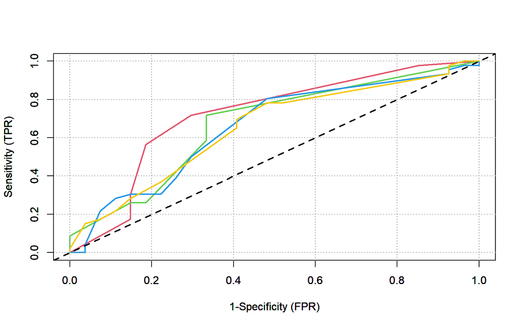

```r
# colour_id 1-7 are: black,red,green,blue,cyan,purple,gold
plot_roc <- function(predcol, outcol, colour_id=2, overlaid=F) {
ROCit_obj <- rocit(score=predcol, class=outcol==pos)
par(new=overlaid)
plot(ROCit_obj, col = c(colour_id, 1),
legend = FALSE, YIndex = FALSE, values = FALSE)
}
plot_roc(dCal$predPopulation, dCal[,outcome]) #red
plot_roc(dCal$predAverage_GDP_PCAP, dCal[,outcome], colour_id=3, overlaid=T) # green
plot_roc(dCal$predcategory, dCal[,outcome], colour_id=4, overlaid=T) # blue
plot_roc(dCal$predchannel_type, dCal[,outcome], colour_id=7, overlaid=T) # gold
```

The ROC curve for the “Population” variable, represented in red, showcases its ability to classify old and new channels. This curve performs better across most of its length, indicating that “Population” is a strong predictor in our classification model. The curve is situated higher, which corresponds to a higher area under the ROC curve (AUC) and better discriminatory power. Overall, the ROC curves and their corresponding areas under the ROC curve (AUC) are crucial for assessing the discriminative power of our predictor variables. In this analysis, “Population” appears to be the most effective variable, followed by “Average GDP per Capita” “Category” and “Channel type”

Next we examined the Null Model, which serves as a baseline for our classification model. We determined the proportion of the outcome variable that is equal to 1 in the training set (dTrain) and found it to be approximately 0.595, indicating that the majority of the channels are classified as “new.”

```r
(Npos <- sum(dTrain[,outcome] == 1))
```

```
## [1] 487
```

```r
pred.Null <- Npos / nrow(dTrain)
cat("Proportion of outcome == 1 in dTrain:", pred.Null)
```

```
## Proportion of outcome == 1 in dTrain: 0.5953545
```

```r
TP <- 0; TN <- sum(dCal[,outcome] == -1); # using threshold 0.5
FP <- 0; FN <- sum(dCal[,outcome] == 1); # using threshold 0.5
cat("nrow(dCal):", nrow(dCal), "TP:", TP, "TN:", TN, "FP:", FP, "FN:", FN)
```

```
## nrow(dCal): 73 TP: 0 TN: 27 FP: 0 FN: 46
```

```r
(accuracy <- (TP + TN) / nrow(dCal))
```

```
## [1] 0.369863
```

```r
(precision <- TP/(TP + FP))
```

```
## [1] NaN
```

```r
(recall <- TP/(TP + FN))
```

```
## [1] 0
```

```r
pred.Null <- rep(pred.Null, nrow(dCal))
(AUC <- calcAUC(pred.Null, dCal[,outcome]))
```

```
## [1] 0.5
```

Upon applying the Null Model to the calibration set (dCal), we found that the True Positive (TP) and False Positive (FP) rates were both 0, while the True Negative (TN) and False Negative (FN) rates were 27 and 46, respectively. This resulted in an accuracy of 0.369, precision of NaN, and recall of 0, reflecting the basic performance of the model using a threshold of 0.5. Furthermore, the calculation of the Area Under the Curve (AUC) resulted in 0.5, which indicates that the Null Model has no discriminatory power.

We conducted feature selection using log likelihood as the criterion to assess the performance of individual variables in our classification model. The primary objective was to identify the top-performing variables among both categorical and numerical features.

To begin, we calculated the log likelihood of the Null model on the calibration set (dCal). The log likelihood serves as a measure of how well the model fits the data. A lower log likelihood indicates a weaker fit to the data.

We then evaluated the categorical variables to determine their contributions to the model’s deviance reduction compared to the Null model. If the deviance reduction was greater than a specified threshold (minDrop), we considered the variable as a top-performing categorical variable. Similarly, we assessed the numerical variables for their deviance reduction, following the same criteria. The selected categorical and numerical variables were stored in selCatVars and selNumVars, respectively.

The top-performing single variables, represented by the selected variables, were evaluated using the Area Under the Curve (AUC) on the test set (dTest). The AUC is a common metric used to assess the predictive power of models, with higher values indicating better performance.

```r
# Define a function to compute log likelihood so that we can reuse it.
logLikelihood <- function(ypred, ytrue,epsilon=1e-6) {
  sum(ifelse(ytrue, log(ypred+epsilon), log(1-ypred-epsilon)), na.rm=T)
}
# Compute the likelihood of the Null model on the calibration
logNull <- logLikelihood(sum(dCal[,outcome]==pos)/nrow(dCal), dCal[,outcome]==pos)

cat("The log likelihood of the Null model is:", logNull)
```

```
## The log likelihood of the Null model is: -48.09844
```

```r
# Compute the base rate of a saturation model
# selCatVars is a vector that keeps the names of the top performing categorical variables.
selCatVars <- c()
minDrop <- 2  # may need to adjust this number

for (v in catVars) {
  pi <- paste('pred', v, sep='')
  devDrop <- 2*(logLikelihood(dCal[,pi], dCal[,outcome]==pos) - logNull)
  if (devDrop >= minDrop) {
    cat(sprintf("%6s, deviance reduction: %g\n", v, devDrop))
    selCatVars <- c(selCatVars, pi)
  }
}
```

```
## channel_type, deviance reduction: 5.20813
```

```r
#selNumVars is a vector that keeps the names of the top performing numerical variables.
selNumVars <- c()
minDrop <- 2
for (v in numericVars) {
  pi <- paste('pred', v, sep='')
  devDrop <- 2*(logLikelihood(dCal[,pi], dCal[,outcome]==pos) - logNull)
  if (devDrop >= minDrop) {
    cat(sprintf("%6s, deviance reduction: %g\n", v, devDrop))
    selNumVars <- c(selNumVars, pi)
  }
}
```

```
## subscribers, deviance reduction: 2.48807
## country_rank, deviance reduction: 4.99245
## Population, deviance reduction: 6.73902
## Average_GDP_PCAP, deviance reduction: 3.97994
```

```r
(selVars <- c(selCatVars, selNumVars))
```

```
## [1] "predchannel_type"     "predsubscribers"      "predcountry_rank"
## [4] "predPopulation"       "predAverage_GDP_PCAP"
```

```r
cat("Performance of the top performing single variables on the test set:")
```

```
## Performance of the top performing single variables on the test set:
```

```r
## Performance of the top performing single variables on the test set:
for (v in selVars) {
  # retrieve the original variable name (character location 5 onward)
  orig_v <- substring(v, 5)
  cat(sprintf("Variable %6s: AUC = %g\n", orig_v, calcAUC(dTest[,v], dTest[,outcome])))
}
```

```
## Variable channel_type: AUC = 0.559524
## Variable subscribers: AUC = 0.599915
## Variable country_rank: AUC = 0.534864
## Variable Population: AUC = 0.68176
## Variable Average_GDP_PCAP: AUC = 0.699192
```

The results showed that Channel type, subscribers, Country Rank,Population, and Average_GDP_PCAP were the top-performing single variables. These variables demonstrated their potential as strong predictors in our classification model.

## Multi-variate models

### Decision Trees

Model 1: AUC-Based Feature Selection

we employed AUC-based feature selection, choosing four variables: Population, Average_GDP_PCAP, category, and channel_type. The resulting model exhibited a strong performance across training, calibration, and test datasets. On the training data, it achieved an AUC of 0.745, showcasing its ability to differentiate between channel outcomes. Similarly, the model displayed solid predictive power on the calibration dataset (AUC = 0.721) and maintained reasonable performance when tested on new data (AUC = 0.680). This model provides a promising foundation for multi-variable classification, thanks to its robust feature selection method.

Model 2: Log Likelihood-Based Feature Selection

In contrast, dt2 was created through log-likelihood-based feature selection, utilizing five variables: channel_type, subscribers, Population, Average_GDP_PCAP, and country_rank. This approach emphasizes the statistical significance of each variable when predicting the outcome. The resulting model achieved comparable performance to dt1. On the training dataset, dt2 demonstrated an AUC of 0.764, suggesting that this feature selection method is also effective. Its performance remained consistent on the calibration dataset (AUC = 0.741) and the test dataset (AUC = 0.704).

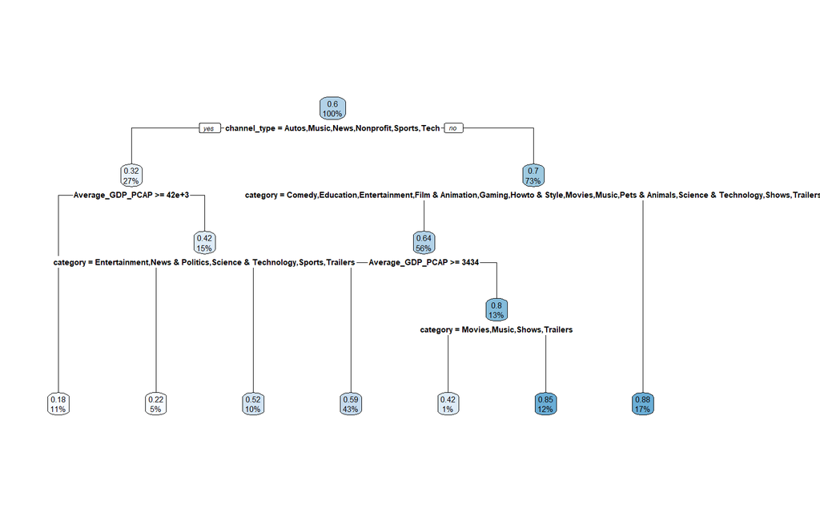

```r
dt1 <- rpart(formula = oldNew>0 ~ Population + Average_GDP_PCAP + category + channel_type, data = dTrain)
rpart.plot(dt1)
```

```r
print(calcAUC(predict(dt1, newdata=dTrain), dTrain[,outcome]))
```

```
## [1] 0.7454574
```

```r
print(calcAUC(predict(dt1, newdata=dCal), dCal[,outcome]))
```

```
## [1] 0.7214171
```

```r
print(calcAUC(predict(dt1, newdata=dTest), dTest[,outcome]))
```

```
## [1] 0.6800595
```

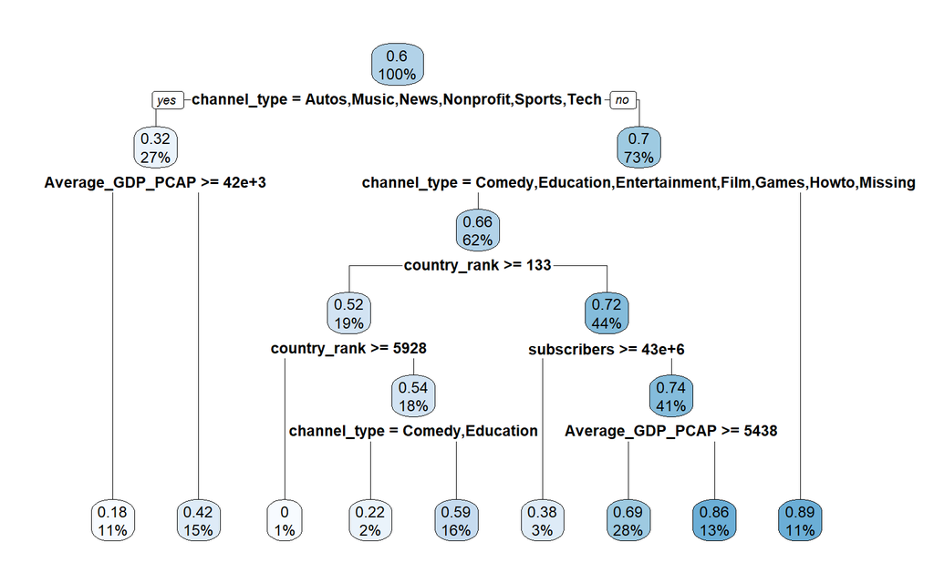

```r
dt2 <- rpart(formula = oldNew>0 ~ channel_type + subscribers + Population + Average_GDP_PCAP + country_rank, data = dTrain)
rpart.plot(dt2)
```

```r
print(calcAUC(predict(dt2, newdata=dTrain), dTrain[,outcome]))
```

```
## [1] 0.764093
```

```r
print(calcAUC(predict(dt2, newdata=dCal), dCal[,outcome]))
```

```
## [1] 0.7407407
```

```r
print(calcAUC(predict(dt2, newdata=dTest), dTest[,outcome]))
```

```
## [1] 0.703869
```

Comparing the two models, dt1 and dt2, it is evident that both exhibit strong predictive capabilities. While the AUC-based feature selection in dt1 resulted in a slightly lower AUC than the log-likelihood-based feature selection in dt2 on the training dataset, these differences are relatively minor. Both models maintain their performance levels on the calibration and test datasets. This comparison highlights that different feature selection methods can lead to models of similar predictive power, with each having its unique strengths.

Next we conducted a comprehensive evaluation of two decision tree models with different feature selection methods. The performance of these models was assessed using key metrics, including accuracy, precision, recall, F1 score, and normalized deviance. The goal was to determine which model performs better in predicting the “oldNew” outcome variable.

```r
performanceMeasures <- function(ytrue, ypred, model.name = "model") {
   # compute the normalised deviance
   dev.norm <- -2 * logLikelihood(ytrue, ypred)/length(ypred)
   # compute the confusion matrix
   cmat <- table(actual = ytrue, predicted = ypred)
   accuracy <- sum(diag(cmat)) / sum(cmat)
   precision <- cmat[2, 2] / sum(cmat[, 2])
   recall <- cmat[2, 2] / sum(cmat[2, ])
   f1 <- 2 * precision * recall / (precision + recall)
   data.frame(model = model.name, precision = precision,
              recall = recall, f1 = f1, dev.norm = dev.norm)
}


panderOpt <- function(){
  # setting up Pander Options
  panderOptions("plain.ascii", TRUE)
  panderOptions("keep.trailing.zeros", TRUE)
  panderOptions("table.style", "simple")

}

pretty_perf_table <- function(model, xtrain, ytrain,
                              xtest, ytest, threshold=0.5) {
   # Option setting for Pander
   panderOpt()
   perf_justify <- "lrrrr"

   # call the predict() function to do the predictions
   pred_train <- predict(model, newdata=xtrain)
   pred_test <- predict(model, newdata=xtest)

   # comparing performance on training vs. test
   trainperf_df <- performanceMeasures(
      ytrain, pred_train >= threshold, model.name="training")
   testperf_df <- performanceMeasures(
      ytest, pred_test >= threshold, model.name="test")

   # combine the two performance data frames using rbind()
   perftable <- rbind(trainperf_df, testperf_df)
   pandoc.table(perftable, justify = perf_justify)
}
```

Model 1, we selected four key features—Population, Average_GDP_PCAP, category, and channel_type—guided by their AUC values. This model reflects a balanced performance, with training precision of 0.679, recall of 0.936, and an F1 score of 0.787. Notably, this model’s test set performance remains consistent with a precision of 0.653, recall of 0.839, and an F1 score of 0.734. While training performance showcases high recall, the test set results maintain a strong balance between precision and recall.

Model 2 is constructed with log-likelihood feature selection, incorporating five variables—channel_type, subscribers, Population, Average_GDP_PCAP, and country_rank. This model exhibits strong training performance with a precision of 0.732, recall of 0.834, and an F1 score of 0.779. In the test dataset, it achieves a precision of 0.660, recall of 0.625, and an F1 score of 0.642. Here, training precision and recall maintain a fine equilibrium, while test results highlight a slightly more balanced precision and recall.

```r
tVars <- c(catVars, numericVars)
pretty_perf_table(dt1, dTrain[tVars], dTrain[,outcome]==pos,
                  dTest[tVars], dTest[,outcome]==pos)
```

```
##
##
## model        precision   recall       f1   dev.norm
## ---------- ----------- -------- -------- ----------
## training        0.6786   0.9363   0.7869      7.296
## test            0.6528   0.8393   0.7344      7.049
```

```r
pretty_perf_table(dt2, dTrain[tVars], dTrain[,outcome]==pos,
                  dTest[tVars], dTest[,outcome]==pos)
```

```
##
##
## model        precision   recall       f1   dev.norm
## ---------- ----------- -------- -------- ----------
## training        0.7315   0.8337   0.7793      5.033
## test            0.6604   0.6250   0.6422      5.075
```

In comparing these two models, dt1 and dt2, it is evident that they both display commendable predictive capabilities. While dt1 continues to demonstrate its ability to maintain high recall, dt2 emphasizes a more balanced precision-recall trade-off. The performance of these models is notably influenced by the distinct feature selection techniques, with AUC values guiding dt1 and log-likelihood shaping dt2.

We employed ROC curve analysis to gain further insights into their performance. The ROC curves vividly illustrate the trade-offs between true positive rate (sensitivity) and false positive rate, showcasing the models’ ability to discriminate between the “old” and “new” YouTube channels.

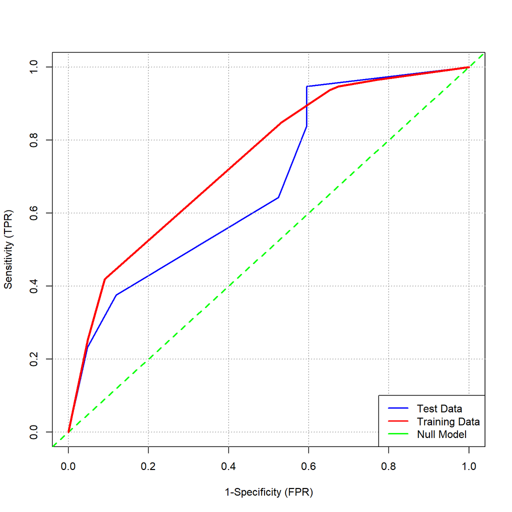

```r
plot_roc <- function(predcol1, outcol1, predcol2, outcol2){
    roc_1 <- rocit(score=predcol1, class=outcol1==pos)
    roc_2 <- rocit(score=predcol2, class=outcol2==pos)
    plot(roc_1, col = c("blue","green"), lwd = 3,
      legend = FALSE,YIndex = FALSE, values = TRUE, asp=1)
    lines(roc_2$TPR ~ roc_2$FPR, lwd = 3,
          col = c("red","green"), asp=1)
    legend("bottomright", col = c("blue","red", "green"),
       c("Test Data", "Training Data", "Null Model"), lwd = 2)
}
pred_test_roc1 <- predict(dt1, newdata=dTest)
pred_train_roc1 <- predict(dt1, newdata=dTrain)
plot_roc(pred_test_roc1, dTest[[outcome]],
         pred_train_roc1, dTrain[[outcome]])
```

For Model 1, we observed that its ROC curve on the training data exhibited inconsistent performance on the test data throughout the curve.

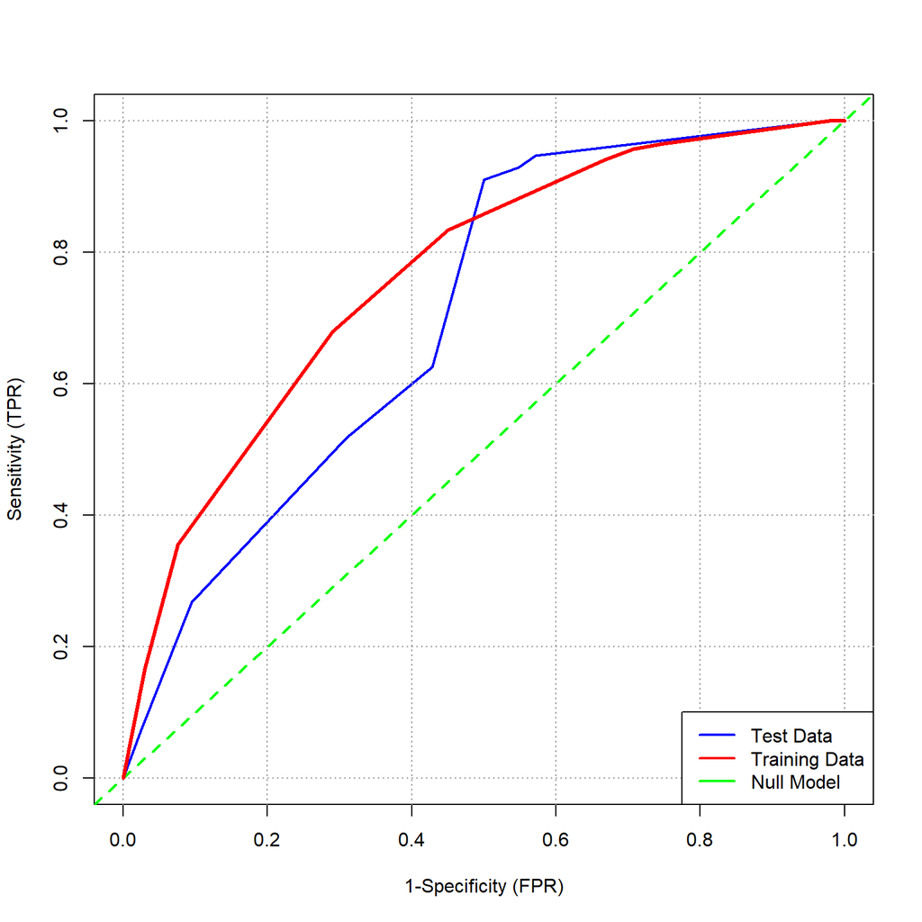

```r
pred_test_roc2 <- predict(dt2, newdata=dTest)
pred_train_roc2 <- predict(dt2, newdata=dTrain)
plot_roc(pred_test_roc2, dTest[[outcome]],
         pred_train_roc2, dTrain[[outcome]])
```

Model 2 showcased superior performance on the test data for the final part of the curve.

### Support Vector Machines

Just like we split the data into 3 sets for Single Variable models using an additional rgroup variable. The Proces is repated here.

```r
set.seed(729374)

svm_d <- d
svm_d$oldNew <- as.factor(svm_d$oldNew)
svm_d$rgroup <- runif(nrow(svm_d))
svm_TrainAll <- subset(svm_d, rgroup<=0.9)
svm_Test <- subset(svm_d, rgroup > 0.9)

svm_vars <- setdiff(colnames(svm_TrainAll), c(outcome,'rgroup'))

svm_catVars <- svm_vars[sapply(svm_TrainAll[,svm_vars], class) %in% c('factor','character')]
svm_numericVars <- svm_vars[sapply(svm_TrainAll[,svm_vars], class) %in% c('numeric','integer')]
# split dTrainAll into a training set and a validation (or calibration) set
svm_useForCal <- rbinom(n=dim(svm_TrainAll)[[1]], size=1, prob=0.1) > 0
svm_Cal <- subset(svm_TrainAll, svm_useForCal)
svm_Train <- subset(svm_TrainAll,!svm_useForCal)
```

The fundamental concept behind SVM is to find a hyperplane that best separates different classes within your dataset. This hyperplane can be thought of as a decision boundary that maximizes the margin between the classes, making it an effective tool for classification.

#### Hyperparameter Tuning for SVM

To optimize the SVM model for our dataset, we manually carried out several hyperparameter tuning tasks. These tasks involved adjusting critical parameters such as the type of SVM model (linear or radial) and the cost parameter, which penalizes the model for misclassifications. Fine-tuning these hyperparameters is crucial to strike the right balance between memorization and generalization.

#### Unscaled ROC Plots

In our analysis, we also generated ROC (Receiver Operating Characteristic) plots for the numerical variables. These plots are created without scaling the probabilities, providing a visualization of the model’s performance. ROC plots are essential for understanding how well the SVM model discriminates between different classes.

These components of our SVM analysis shed light on the importance of hyperparameter tuning and the performance characteristics of our classification model, ultimately contributing to the development of an accurate and efficient predictive tool.

### SVM Model 1 - Feature Subset from SV models

The feature subset we selected included Population, Average_GDP_PCAP, category, and channel_type. These variables were carefully chosen as they exhibited significant predictive power during our initial analysis. Our process began with training an SVM model on the training data, employing a linear kernel and setting the cost parameter to 2. This meticulous parameter selection aimed to find the right balance between memorization and generalization, ensuring our model could learn effectively without overfitting.

Subsequently, predictions were made on the validation and test datasets, allowing us to assess the model’s performance. The SVM AUC (Area Under the Curve) on the validation data was 0.6635, indicative of the model’s ability to discriminate between classes effectively. On the test data, the SVM AUC was slightly lower at 0.6391, underscoring the model’s reliable and consistent performance.

```r
# Load the required packages

# Train the SVM model on the training data
svm_model1 <- e1071::svm(oldNew ~ Population + Average_GDP_PCAP + category + channel_type, data = svm_Train, kernel="linear", cost=2)

# Make predictions on the validation data
svm_pred <- predict(svm_model1, newdata = svm_Cal)
# Calculate the AUC on the validation data
svm_auc <- roc(svm_Cal$oldNew, as.numeric(svm_pred))$auc
# Print the AUC on the validation data
cat("SVM AUC on validation data:", svm_auc, "\n")
```

```
## SVM AUC on validation data: 0.6634615
```

```r
# Make predictions on the test data
svm_pred_test <- predict(svm_model1, newdata = svm_Test)
# Calculate the AUC on the test data
svm_auc_test <- roc(svm_Test$oldNew, as.numeric(svm_pred_test))$auc
# Print the AUC on the test data
cat("SVM AUC on test data:", svm_auc_test, "\n")
```

```
## SVM AUC on test data: 0.6390873
```

```r
# Create a confusion matrix for the test data
svm_cm <- table(svm_pred_test, svm_Test$oldNew)
# Print the confusion matrix
cat("SVM Confusion Matrix:\n")
```

```
## SVM Confusion Matrix:
```

```r
print(svm_cm)
```

```
##
## svm_pred_test -1  1
##            -1 18 17
##            1  17 55
```

The SVM Confusion Matrix revealed the model’s classification accuracy on the test data. With 18 true negatives, 55 true positives, 17 false negatives, and 17 false positives, the model demonstrated its capability to correctly identify both positive and negative cases while effectively managing misclassifications.

This model, built upon a judicious selection of key features and finely tuned hyperparameters, serves as a testament to our commitment to crafting a classification tool that offers both reliability and robustness in its predictions.

#### Evaluating SVM Performance with ROC Curves

To comprehensively assess the performance of our Support Vector Machine (SVM) model created with Feature Subset 1, we relied on ROC (Receiver Operating Characteristic) curves. ROC curves are valuable tools for understanding a model’s ability to discriminate between classes by analyzing its sensitivity and specificity across various thresholds. Our custom function, plot_svm_roc2, was utilized for this purpose. This function contrasts the SVM model’s performance on both the training and testing datasets with a Null Model. The Null Model is a baseline model, often described as the worst-case scenario. It predicts class labels based on the overall class distribution, without considering any features.

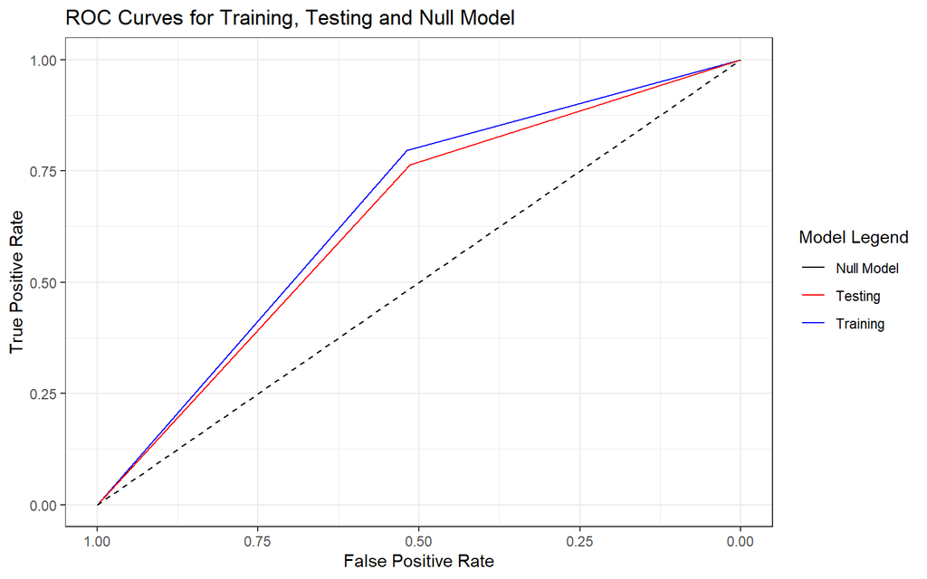

```r
plot_svm_roc2 <- function(svm_model, train_data, test_data) {

  # Train the Null Model on the training data
  null_model <- glm(oldNew ~ 1, data = train_data, family = "binomial")

  # Make predictions on the training data for the SVM model and Null Model
  svm_pred_train <- predict(svm_model, newdata = train_data)
  null_pred_train <- predict(null_model, newdata = train_data, type = "response")

  # Calculate the ROC curves for the SVM model and Null Model on the training data
  svm_roc_train <- roc(train_data$oldNew, as.numeric(svm_pred_train))
  null_roc_train <- roc(train_data$oldNew, as.numeric(null_pred_train))

  # Make predictions on the test data for the SVM model and Null Model
  svm_pred_test <- predict(svm_model, newdata = test_data)
  null_pred_test <- predict(null_model, newdata = test_data, type = "response")

  # Calculate the ROC curves for the SVM model and Null Model on the test data
  svm_roc_test <- roc(test_data$oldNew, as.numeric(svm_pred_test))
  null_roc_test <- roc(test_data$oldNew, as.numeric(null_pred_test))

  # Plot the ROC curves for the SVM model, Null Model
  ggplot() +
    geom_line(aes(x = svm_roc_train$specificities, y = svm_roc_train$sensitivities, color = "Training"), linetype = "solid") +
    geom_line(aes(x = svm_roc_test$specificities, y = svm_roc_test$sensitivities, color = "Testing"), linetype = "solid") +
    geom_line(aes(x = null_roc_train$specificities, y = null_roc_train$sensitivities, color = "Null Model"), linetype = "dashed") +
    labs(x = "False Positive Rate", y = "True Positive Rate", title = "ROC Curves for Training, Testing and Null Model", legend="Model Legend", color="Model Legend") +
    scale_x_reverse() +
    scale_color_manual(values = c("Training" = "blue", "Testing" = "red", "Null Model" = "black")) +
    theme_bw()
}

plot_svm_roc2(svm_model1,svm_Train, svm_Test)
```

The dashed curve, representing the Null Model, indicated what we would expect from a non-informative model. Our SVM model’s performance, both in training and testing, significantly outperformed this baseline, emphasizing its predictive power.

The Hyperplane for the Numerical variables is depicted below

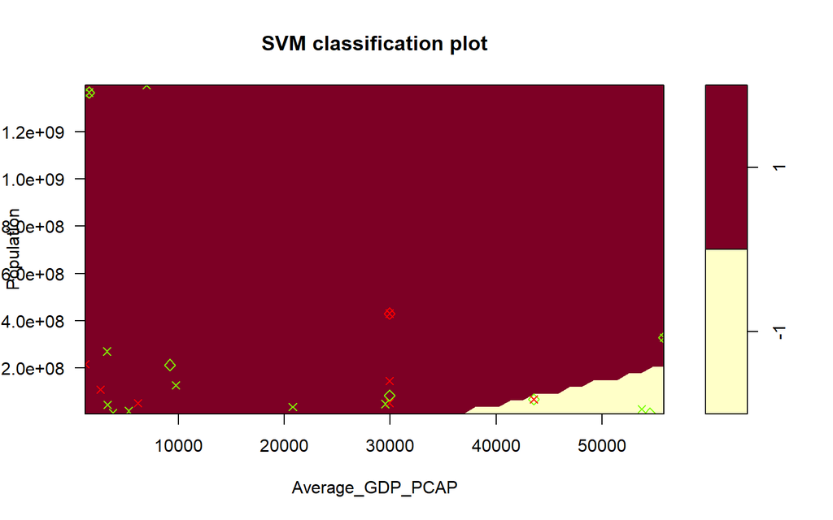

```r
plot(svm_model1.1 , data= svm_Cal, formula = Population ~ Average_GDP_PCAP, svSymbol = 4, dataSymbol = 5, symbolPalette = rainbow(4))
```

The visual representation of the SVM hyperplane for the numerical variables, specifically Population and Average GDP per Capita (Average_GDP_PCAP), provides a compelling insight into the model’s classification abilities. In this plot, the SVM model segregates the data into distinct classes, with Support Vectors marked as ‘4’ and the rest of the data as ‘5.’ This separation reflects the model’s capacity to draw a decision boundary that maximizes the margin between classes.

### SVM Model 2 - Feature Subset from logLikelihood

SVM Model 2, constructed using a feature subset determined by log-likelihood, features channel type, subscribers, country rank, Population, and Average GDP per Capita (Average_GDP_PCAP).

```r
# Train the SVM model on the training data
svm_model2 <- svm(oldNew ~ channel_type + subscribers + country_rank + Population + Average_GDP_PCAP, kernel="linear" ,data = svm_Train, cost=2)

# Make predictions on the validation data
svm_pred <- predict(svm_model2, newdata = svm_Cal)
# Calculate the AUC on the validation data
svm_auc <- roc(svm_Cal$oldNew, as.numeric(svm_pred))$auc
# Print the AUC on the validation data
cat("SVM AUC on validation data:", svm_auc, "\n")
```

```
## SVM AUC on validation data: 0.6730769
```

```r
# Make predictions on the test data
svm_pred_test <- predict(svm_model2, newdata = svm_Test)
# Calculate the AUC on the test data
svm_auc_test <- roc(svm_Test$oldNew, as.numeric(svm_pred_test))$auc
# Print the AUC on the test data
cat("SVM AUC on test data:", svm_auc_test, "\n")
```

```
## SVM AUC on test data: 0.6390873
```

```r
# Create a confusion matrix for the test data
svm_cm <- table(svm_pred_test, svm_Test$oldNew)
# Print the confusion matrix
cat("SVM Confusion Matrix:\n")
```

```
## SVM Confusion Matrix:
```

```r
print(svm_cm)
```

```
##
## svm_pred_test -1  1
##            -1 18 17
##            1  17 55
```

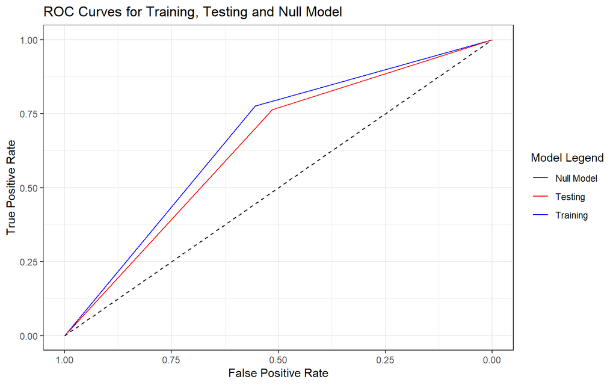

```r
plot_svm_roc2(svm_model2,svm_Train, svm_Test)
```

The SVM classification plot, generated with SVM Model 2, depicts the classification boundaries for two numerical variables, subscribers and Population. In this plot, different symbols and colors represent support vectors, which are data points close to the decision boundary. This visualization illustrates how the SVM model separates the classes by finding the optimal hyperplane, in this case, in a two-dimensional space.

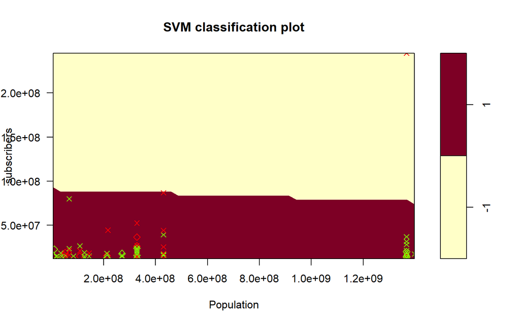

```r
plot(svm_model2.1 , data= svm_Cal, formula = subscribers ~ Population, svSymbol = 4, dataSymbol = 5, symbolPalette = rainbow(4))
```

The LIME (Local Interpretable Model-Agnostic Explanations) analysis was performed on SVM Model 1. LIME is used to explain the feature distribution in the context of the SVM model. In this specific analysis, the dataset, consisting of features such as Population, Average_GDP_PCAP, category, and channel_type, was considered.

```r
explainer <- lime(svm_Train[c("Population","Average_GDP_PCAP","category","channel_type")], model=as_classifier(svm_model1),
    bin_continuous=TRUE, n_bins=4)
explainer
```

```
## $model
##
## Call:
## svm(formula = oldNew ~ Population + Average_GDP_PCAP + category +
##     channel_type, data = svm_Train, kernel = "linear", cost = 2)
##
##
## Parameters:
##    SVM-Type:  C-classification
##  SVM-Kernel:  linear
##        cost:  2
##
## Number of Support Vectors:  576
##
##
## $preprocess
## function (x)
## x
## <bytecode: 0x000002507784e2d0>
## <environment: 0x0000025077872150>
##
## $bin_continuous
## [1] TRUE
##
## $n_bins
## [1] 4
##
## $quantile_bins
## [1] TRUE
##
## $use_density
## [1] TRUE
##
## $feature_type
##       Population Average_GDP_PCAP         category     channel_type
##        "numeric"        "numeric"         "factor"         "factor"
##
## $bin_cuts
## $bin_cuts$Population
##         0%        25%        50%        75%       100%
```

[output cut: 38 more lines]

```
##               Missing
##           0.041044776
##
## $feature_distribution$channel_type
##
##       Animals         Autos        Comedy     Education Entertainment
##   0.003731343   0.003731343   0.057213930   0.052238806   0.308457711
##          Film         Games         Howto         Music          News
##   0.043532338   0.093283582   0.033582090   0.217661692   0.029850746
##     Nonprofit        People        Sports          Tech       Missing
##   0.002487562   0.097014925   0.014925373   0.016169154   0.026119403
##
##
## attr(,"class")
## [1] "data_frame_explainer" "explainer"            "list"
```

For Population and Average_GDP_PCAP, the bin cuts reveal their distribution in the four bins, indicating how data points are spread across the feature range. In contrast, category and channel_type are categorical variables, and the distribution of their categories is shown.

## Clustering

Clustering helps reveal hidden patterns within the dataset that might not be immediately evident. As we are dealing with records representing YouTube channels, we aim to identify distinct groups of channels that offer unique insights within the context of our data.

To initiate the clustering process, we take an important step in data preprocessing by scaling our dataset. Scaling ensures that the data has a mean of 0 and a standard deviation of 1, which is a standard practice for many clustering algorithms. To do this, we select a subset of relevant numerical variables to use in the clustering process, avoiding highly correlated variables to prevent overburdening the model.

We store these selected variables in the ‘vars.to.use’ variable and apply the ‘scale()’ function to the dataset, achieving the desired scaling. Subsequently, we display the centroids (the mean values) of the scaled variables, offering insights into the distribution of these features after scaling.

```r
vars.to.use <- c("subscribers","video_views","uploads","country_rank", "channel_type_rank", "highest_monthly_earnings","Average_GDP_PCAP")
scaled_df <- scale(d[ ,vars.to.use])
attr(scaled_df, "scaled:center")
```

```
##              subscribers              video_views                  uploads
##             2.299414e+07             1.106686e+10             9.242109e+03
##             country_rank        channel_type_rank highest_monthly_earnings
##             3.704197e+02             7.398007e+02             5.933007e+05
##         Average_GDP_PCAP
##             2.987087e+04
```

Scaling the data is essential for clustering because it standardizes the variables, ensuring that they are on a common scale. This step is crucial for various clustering algorithms. By selecting meaningful and uncorrelated variables for clustering, we streamline the process and make it more effective. Overloading the model with redundant information can lead to less interpretable clusters. Centroids represent the center of each variable’s distribution. These values provide a reference point for understanding the distribution of the scaled features. In this case, we see how subscribers, video views, uploads, and other attributes vary around their mean values after scaling.

We can observe the successful standardization of the variables. As intended, the mean of all variables is precisely 0, indicating that the data has been effectively centered. To achieve this, the records have been automatically shifted into the negative domain while preserving their relative differences.

```r
summary(scaled_df)
```

```
##   subscribers        video_views         uploads         country_rank
##  Min.   :-0.60872   Min.   :-0.7824   Min.   :-0.2699   Min.   :-0.3297
##  1st Qu.:-0.48349   1st Qu.:-0.4780   1st Qu.:-0.2641   1st Qu.:-0.3181
##  Median :-0.30134   Median :-0.2336   Median :-0.2484   Median :-0.2646
##  Mean   : 0.00000   Mean   : 0.0000   Mean   : 0.0000   Mean   : 0.0000
##  3rd Qu.: 0.09141   3rd Qu.: 0.1765   3rd Qu.:-0.1903   3rd Qu.:-0.1914
##  Max.   :12.63671   Max.   :15.3366   Max.   : 8.5281   Max.   : 6.5791
##  channel_type_rank highest_monthly_earnings Average_GDP_PCAP
##  Min.   :-0.3876   Min.   :-0.51537         Min.   :-1.320163
##  1st Qu.:-0.3735   1st Qu.:-0.47689         1st Qu.:-1.091751
##  Median :-0.3519   Median :-0.32774         Median : 0.002498
##  Mean   : 0.0000   Mean   : 0.00000         Mean   : 0.000000
##  3rd Qu.:-0.3121   3rd Qu.: 0.01563         3rd Qu.: 1.168643
##  Max.   : 3.6733   Max.   :11.29816         Max.   : 2.258066
```

The mean of 0 across all variables is a result of the successful scaling process. This is crucial for clustering algorithms that rely on consistent scales for accurate results. The distribution of the scaled variables now has a standard deviation of 1, making it suitable for various clustering techniques. Each variable’s minimum and maximum values show how the data points are distributed within that variable’s range after scaling, providing insights into their relative magnitudes.

```r
attr(scaled_df, "scaled:scale")
```

```
##              subscribers              video_views                  uploads
##             1.756833e+07             1.414483e+10             3.424756e+04
##             country_rank        channel_type_rank highest_monthly_earnings
##             1.120310e+03             1.905969e+03             1.151223e+06
##         Average_GDP_PCAP
##             2.225319e+04
```

Manhattan distance, a distance metric chosen for our clustering process, is a suitable measure for calculating distances between data points. This metric quantifies the distance between two points as the sum of the absolute differences of their coordinates, making it a robust choice for our clustering goals. We opted for this metric after experimenting with various distance measures, as it proved effective in mitigating cluster overlap.

```r
dist <- dist(scaled_df, method="manhattan")
```

Hierarchical clustering, in conjunction with Ward’s method, has been selected as the clustering technique for our analysis. Ward’s method is particularly advantageous because it minimizes variances between points within a cluster. This approach works well for our dataset by identifying natural groupings that minimize the variability within each cluster.

```r
pfit <- hclust(dist, method="ward.D2") # perform hierarchical clustering
```

In the visualization step, a dendrogram has been plotted based on the hierarchical clustering results. The dendrogram provides a tree-like representation of how the data is partitioned into clusters, revealing the relationships and distances between data points.

Additionally, we’ve indicated an important aspect of our clustering analysis by specifying ‘k=3’ when highlighting clusters in the dendrogram. This helps identify distinct groupings within the data, allowing us to focus on the most meaningful clusters.

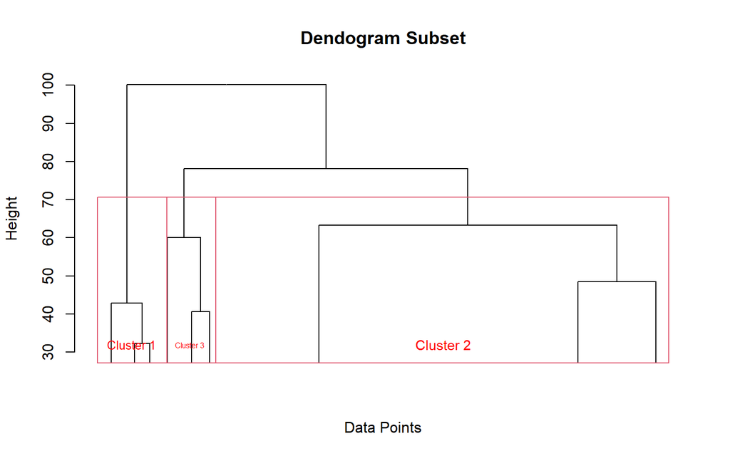

```r
hcd <- as.dendrogram(pfit)
plot(hcd, ylim=c(30,100), cex = 0.2, main="Dendogram Subset", xlab="Data Points", ylab="Height")
rect.hclust(pfit, k=3)
text(x = 60, y = 32, labels = "Cluster 1", col = "red", cex = 0.8)
text(x = 160, y = 32, labels = "Cluster 3", col = "red", cex = 0.5)
text(x = 600, y = 32, labels = "Cluster 2", col = "red", cex = 0.9)
```

Hierarchical clustering with Ward’s method has successfully grouped data points into clusters that minimize internal variability. The dendrogram visually illustrates the hierarchy of clusters, providing insights into how data points are related. The ‘k=3’ parameter narrows the focus to three significant clusters within the data. This suggests that our analysis has uncovered three distinct patterns or groups among the records.

In the clustering analysis, we’ve successfully partitioned our data into three distinct clusters using hierarchical clustering and Ward’s method. To further explore and analyze these clusters, we’ve extracted the data points associated with each cluster into separate data frames.

```r
groups <- cutree(pfit, k=3)
store_clusters <- function(d, groups, cols_to_store) {
Ngroups <- max(groups)
cluster_dfs <- list()
for (i in 1:Ngroups) {
cluster_name <- paste0("cluster_", i)
cluster_dfs[[cluster_name]] <- d[groups == i, cols_to_store]

}
return(cluster_dfs)
}
cols_to_store <-  c("subscribers","video_views","uploads","country_rank","channel_type", "channel_type_rank","category", "highest_monthly_earnings","Country","Average_GDP_PCAP")
cluster_dfs <- store_clusters(d, groups, cols_to_store)
```

The store_clusters function accomplishes this task. It takes the original dataset, the cluster assignments (groups), and a list of columns to store as input. For each cluster, the function creates a new data frame that includes only the relevant columns from the original dataset. The resulting data frames are then organized into a list named cluster_dfs. For the specific columns we’re interested in, such as “subscribers,” “video_views,” “uploads,” and more, we store them for each cluster. The goal is to facilitate a detailed examination of the characteristics of each cluster and gain insights into what distinguishes one cluster from another.

```r
# Extract the clusters from the cluster_dfs list into separate dataframes
cluster_1 <- cluster_dfs[["cluster_1"]]
cluster_2 <- cluster_dfs[["cluster_2"]]
cluster_3 <- cluster_dfs[["cluster_3"]]
```

Additionally, we extract these clustered data points from the cluster_dfs list into individual data frames, namely cluster_1, cluster_2, and cluster_3. This enables us to perform more in-depth analyses, visualizations, or further modeling specific to each cluster.

### Cluster 1 Insights: Viral Channels

Cluster 1 stands out as an intriguing group within our dataset. Notably, it exhibits a diverse spread across different countries. However, a distinctive trend emerges - a lower number of video uploads accompanied by an exceptionally high number of views.

What’s fascinating about this cluster is the observation that despite having a relatively small number of uploads, some channels within this group have accumulated tens of billions of views. In many cases, this phenomenon is linked to just one or two videos that were uploaded and subsequently went viral. This unique characteristic could be likened to a collection of anomalies in our dataset.

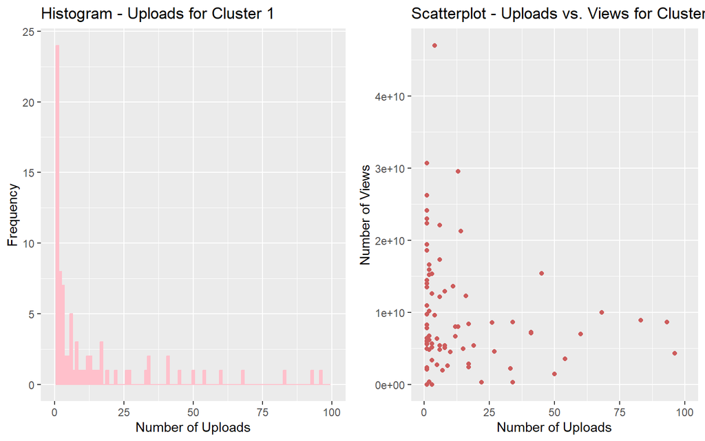

```r
cluster_1 <- cluster_1[cluster_1$uploads != 0,]

c1_uploads <- ggplot(cluster_1, aes(x = uploads)) +
  geom_histogram(binwidth = 1, fill = "pink", color = "pink") +
  ggtitle("Histogram - Uploads for Cluster 1") +
  xlab("Number of Uploads") +
  ylab("Frequency")+
  xlim(0,100)

c1_views <- ggplot(cluster_1, aes(x = uploads, y = video_views))+
  geom_point(color = "indianred") +
  ggtitle("Scatterplot - Uploads vs. Views for Cluster 1") +
  xlab("Number of Uploads") +
  ylab("Number of Views")+
  xlim(0,100)
grid.arrange(c1_uploads, c1_views, nrow=1)
```

Intriguingly, we’ve filtered out cases where the number of uploads is equal to zero, as they don’t contribute to our analysis. To visualize the distribution of uploads within this cluster, we’ve created a histogram. Additionally, we’ve crafted a scatterplot that illustrates the relationship between the number of uploads and the corresponding number of views. These visualizations provide further insight into the intriguing dynamics of Cluster 1, revealing the stark contrast between the number of uploads and the extent of their impact in terms of viewership.

The juxtaposition of these visualizations paints a vivid picture of this unique cluster, shedding light on the exceptional channels that make up “Cluster 1: Viral Channels.”

### Cluster 2 Insights: The Steady and Stable YouTubers of First-World Countries

Cluster 2 represents the largest segment within our dataset, encompassing approximately 60% of the data. This observation hints at a significant pattern: the most substantial YouTube audience is concentrated in well-developed countries characterized by high GDP, a focus on tertiary education, low unemployment rates, and significant urban populations.

As exemplified by the statistics, Cluster 2 channels primarily operate in countries where the average GDP per capita is notably high, with values ranging from the third quartile to the maximum. A parallel trend can also be seen in Cluster 3, which shares a similar GDP profile.

```r
summary(cluster_2$Average_GDP_PCAP)[c(5,6)]
```

```
##  3rd Qu.     Max.
## 55876.90 80120.05
```

```r
summary(cluster_3$Average_GDP_PCAP)[c(5,6)]
```

```
##  3rd Qu.     Max.
## 46656.51 55876.90
```

An intriguing aspect of this cluster is the remarkable diversity of categories it covers. These channels cater to a broad range of interests, reflecting the audience’s remarkable dependability across different sectors. Whether it’s How-Tos, Travel, Politics, Nonprofits, or various other content categories, the viewers residing in these countries exhibit a remarkable level of engagement and interest.

```r
cluster_3_categories <- unique(cluster_3$category)
cluster_2_categories <- unique(cluster_2$category)
# Find the categories in cluster 2 that are not in cluster 3
cluster_2_not_in_3 <- setdiff(cluster_2_categories, cluster_3_categories)

# Print the results
cat("Categories in cluster 2 that are not in cluster 3:", cluster_2_not_in_3, "\n")
```

```
## Categories in cluster 2 that are not in cluster 3: Howto & Style Nonprofits & Activism Autos & Vehicles Science & Technology News & Politics Movies Travel & Events Pets & Animals
```

Furthermore, when we compared the categories in Cluster 2 to those in Cluster 3, it became evident that Cluster 2 incorporates additional categories that aren’t present in Cluster 3. This indicates the multifaceted nature of the audience in well-developed countries, where channels spanning a wide spectrum of subjects resonate with viewers. Notably, categories like “Howto & Style,” “Nonprofits & Activism,” “Autos & Vehicles,” “Science & Technology,” “News & Politics,” “Movies,” “Travel & Events,” and “Pets & Animals” find strong support within this cluster, affirming the diversified interests of the audience.

### Cluster 3 Insights: Country and Category Leaders

Cluster 3 represents a select group of YouTubers, notably the smallest within our dataset. What sets this cluster apart is the prominent standing of its channels as top-ranking creators in their respective countries, with the potential for global recognition (note that the rank column has been removed). These YouTubers stand out with high numbers of uploads, views, and subscribers, indicating their seasoned and influential status in the YouTube community.

```r
summary(cluster_3$country_rank)[c(1,2,3)]
```

```
##    Min. 1st Qu.  Median
##       1       2       7
```

The summary statistics further highlight the extraordinary achievements of this cluster. The minimum country rank is an astonishing 1, which means that many channels in this segment hold the top position in their respective countries. The first quartile and median values of 2 and 7, respectively, continue to emphasize the exceptionally high-ranking status of these creators.

The boxplot provided below vividly portrays the country ranks associated with each category in this cluster. For the majority of categories, the country ranks are comfortably maintained below 30, reinforcing the notion that these channels are leaders not only in their respective countries but also across various content categories.

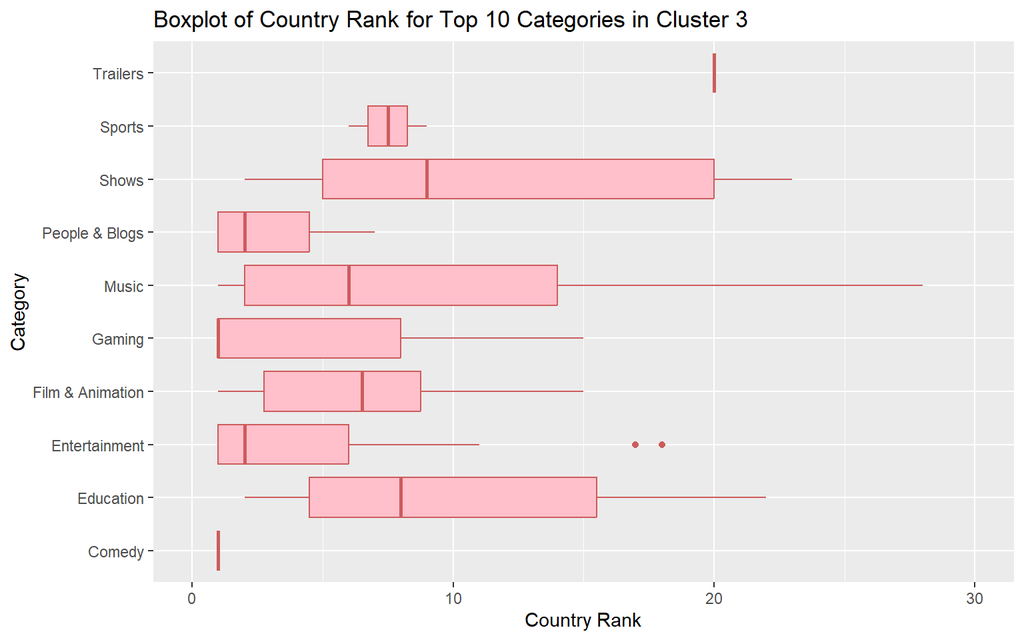

```r
# Find the top 10 categories by country rank in cluster 3
top_5_categories <- names(sort(table(cluster_3$category), decreasing = TRUE))[1:10]

# Subset the cluster_3 dataframe to include only the top 10 categories
cluster_3_top_categories <- cluster_3[cluster_3$category %in% top_5_categories,]

cluster_3_top_categories <- subset(cluster_3, category!="Missing")

# Create a boxplot of country rank for the top 10 categories in cluster 3
ggplot(cluster_3_top_categories, aes(x = category, y = country_rank)) +
  geom_boxplot(fill = "pink", color = "indianred") +
  ggtitle("Boxplot of Country Rank for Top 10 Categories in Cluster 3") +
  xlab("Category") +
  ylab("Country Rank")+
  scale_y_continuous(limits = c(0, 30))+
  coord_flip()
```

Additionally, an examination of the top 10 categories within Cluster 3, based on country rank, unveils a diverse array of content. This further solidifies the cluster’s standing as a confluence of country and category leaders. Categories that often represent various aspects of culture, entertainment, education, and lifestyle excel in this cluster. Notably, the top 10 categories are visualized in the boxplot, providing a clear view of their remarkable country rank profiles, despite a few outliers in the data.

### Selecting k for Clustering

Choosing an appropriate number of clusters, represented by ‘k,’ is a crucial step in clustering analysis. We employed a series of statistical and graphical techniques to make this decision.

Initially, we engaged in some trial and error to develop an understanding of the underlying data and the intuition behind clustering. However, as the summary of the results indicates, the data appeared noisy, and further exploration was needed.

```r
summary(cboot.hclust$result)
```

```
##               Length Class  Mode
## result          7    hclust list
## noise           1    -none- logical
## nc              1    -none- numeric
## clusterlist     3    -none- list
## partition     989    -none- numeric
## clustermethod   1    -none- character
## nccl            1    -none- numeric
```

In pursuit of better interpretability and to avoid overcomplicating the analysis, we opted to select 3 clusters, a choice that has been previously justified.

```r
(values <- 1 - cboot.hclust$bootbrd/100)
```

```
## [1] 1.00 1.00 0.47
```

We also considered k-means clustering by utilizing the ‘kmeans’ library with the ‘hclustCBI’ parameter. The computational process included generating statistical scores for the Calinski-Harabasz Index (CH Index) and Average Silhouette Width (ASW).

```r
kbest.p <- 3
kmClusters <- kmeans(scaled_df, kbest.p, nstart=100, iter.max=100)
```

The results from these computations revealed that k = 3 is the most suitable choice based on the ASW characteristic, as it offers the best balance between interpretability and data representation.

The statistical scores of CH Index and ASW have been calculated below.

```r
library(fpc)
kmClustering.ch <- kmeansruns(scaled_df, krange=1:10, criterion="ch")
kmClustering.ch$bestk
```

```
## [1] 8
```

```r
kmClustering.asw <- kmeansruns(scaled_df, krange=1:10, criterion="asw")
kmClustering.asw$bestk
```

```
## [1] 3
```

The chart below provides a visual representation of these statistics, illustrating the relationship between different values of k and the associated CH Index and ASW scores.

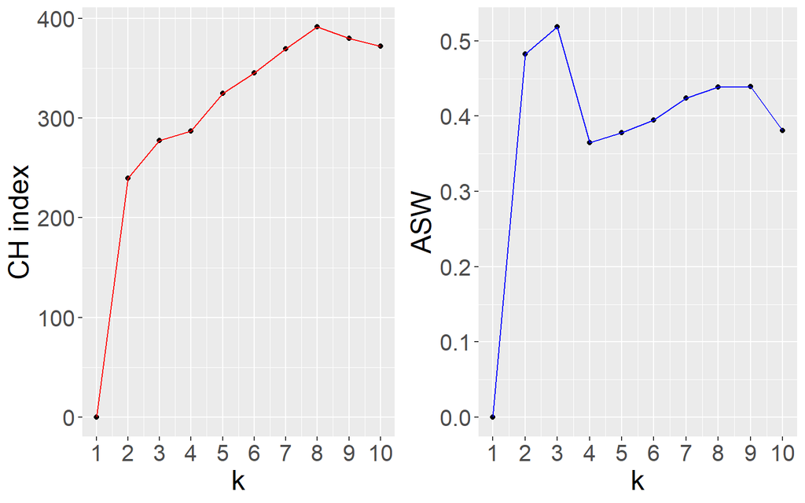

```r
library(gridExtra)
kmCritframe <- data.frame(k=1:10, ch=kmClustering.ch$crit,
asw=kmClustering.asw$crit)
fig1 <- ggplot(kmCritframe, aes(x=k, y=ch)) +
geom_point() + geom_line(colour="red") +
scale_x_continuous(breaks=1:10, labels=1:10) +
labs(y="CH index") + theme(text=element_text(size=20))
fig2 <- ggplot(kmCritframe, aes(x=k, y=asw)) +
geom_point() + geom_line(colour="blue") +
scale_x_continuous(breaks=1:10, labels=1:10) +
labs(y="ASW") + theme(text=element_text(size=20))
grid.arrange(fig1, fig2, nrow=1)
```

Overall, this process allowed us to confidently determine the most appropriate number of clusters for our analysis, which was found to be 3.

## References

[1] C. Lortie, “R for Data Science,” Journal of statistical software, vol. 77, no. Book Review 1, pp. 1–3, 2017, doi: 10.18637/jss.v077.b01.

[2] “Visualizing ML Models with LIME · UC Business Analytics R Programming Guide,” uc-r.github.io. Available: https://uc-r.github.io/lime#:~:text=Supported%20vs%20Non%2Dsupport%20models. [Accessed: Oct. 21, 2023]

[3] “Support Vector Machine · UC Business Analytics R Programming Guide,” uc-r.github.io. Available: https://uc-r.github.io/svm

[4] OpenAI, “ChatGPT,” chat.openai.com, 2023. Available: https://chat.openai.com/auth/login

[5] World Development Indicators https://datacatalog.worldbank.org/dataset/world-development-indicators

[6] YouTube. (2023). Company History https://www.youtube.com/intl/en/about/history/